# Praktikum 6 Anreg

# Library

```r
library(readxl) # untuk membaca data
library(GGally) # untuk menghasilkan matriks hubungan antarpeubah
library(corrplot) # untuk menghasilkan matriks korelasi
library(dplyr) # untuk manipulasi data
library(car) # untuk memeriksa multikolinearitas
library(stargazer) # untuk menampilkan hasil perbandingan regresi
library(lmtest) # untuk uji kehomogenan ragam sisaan dan saling bebas
library(olsrr) # untuk pemeriksaan amatan tidak biasa
```

Data

```r
dt <- read_excel("C:\\Users\\ASUS\\Downloads\\Sosial-Ekonomi mempengaruhi Tingkat Perceraian 2024.xlsx")
dt # menampilkan data
```

```
## # A tibble: 38 × 7
##    Provinsi                  Cerai   RLS   TPT  PDRB    KP   PPM
##    <chr>                     <dbl> <dbl> <dbl> <dbl> <dbl> <dbl>
##  1 Aceh                       1.07  9.64  5.75  10.7  4.58 13.4
##  2 Sumatera Utara             1.01  9.93  5.6   11.2  5.37  7.59
##  3 Sumatera Barat             1.40  9.44  5.75  11.0  4.93  5.70
##  4 Riau                       1.20  9.43  3.7   12.0  4.32  6.52
##  5 Jambi                      1.20  8.9   4.48  11.4  4.33  7.18
##  6 Sumatera Selatan           1.13  8.57  3.86  11.2  4.62 10.7
##  7 Bengkulu                   1.63  9.04  3.11  10.8  4.65 13.0
##  8 Lampung                    1.54  8.36  4.19  10.8  5.64 10.7
##  9 Kepulauan Bangka Belitung  1.45  8.33  4.63  11.2  4.52  4.81
## 10 Kepulauan Riau             1.57 10.5   6.39  12.0  5.58  5.08
## # ℹ 28 more rows
```

```r
str(dt) # menampilkan tipe data setiap peubah
```

```
## tibble [38 × 7] (S3: tbl_df/tbl/data.frame)
##  $ Provinsi: chr [1:38] "Aceh" "Sumatera Utara" "Sumatera Barat" "Riau" ...
##  $ Cerai   : num [1:38] 1.07 1.01 1.4 1.2 1.2 ...
##  $ RLS     : num [1:38] 9.64 9.93 9.44 9.43 8.9 8.57 9.04 8.36 8.33 10.5 ...
##  $ TPT     : num [1:38] 5.75 5.6 5.75 3.7 4.48 3.86 3.11 4.19 4.63 6.39 ...
##  $ PDRB    : num [1:38] 10.7 11.2 11 12 11.4 ...
##  $ KP      : num [1:38] 4.58 5.37 4.93 4.32 4.33 ...
##  $ PPM     : num [1:38] 13.44 7.59 5.7 6.52 7.18 ...
```

```r
summary(dt) # menampilkan ringkasan data
```

```
##    Provinsi             Cerai             RLS              TPT
##  Length:38          Min.   :0.0000   Min.   : 4.210   Min.   :1.320
##  Class :character   1st Qu.:0.8479   1st Qu.: 8.300   1st Qu.:3.217
##  Mode  :character   Median :1.1596   Median : 8.885   Median :4.190
##                     Mean   :1.0451   Mean   : 8.841   Mean   :4.380
##                     3rd Qu.:1.4373   3rd Qu.: 9.515   3rd Qu.:5.713
##                     Max.   :1.8572   Max.   :11.490   Max.   :6.750
##       PDRB              KP             PPM
##  Min.   : 9.804   Min.   :1.609   Min.   : 3.900
##  1st Qu.:10.847   1st Qu.:3.676   1st Qu.: 5.931
##  Median :11.136   Median :4.605   Median : 9.850
##  Mean   :11.157   Mean   :4.711   Mean   :10.905
##  3rd Qu.:11.297   3rd Qu.:5.525   3rd Qu.:13.336
##  Max.   :12.749   Max.   :9.691   Max.   :31.315
```

Data yang digunakan adalah data dari 38 Provinsi di Indonesia pada Tahun 2024 dengan 1 peubah respon yaitu Rasio Cerai dan 5 peubah penjelas yang terdiri dari rata-rata lama sekolah (RLS), persentase tingkat pengangguran terbuka (TPT), Produk Domestik Regional Bruto (PDRB), kepadatan penduduk (KP), dan presentase penduduk miskin (PPM).

Untuk mempermudah dalam komputasi, karena peubah provinsi tidak digunakan, maka dapat dihapus.

```r
dt <- select(dt, -Provinsi)
```

# Eksplorasi Data

## Peubah Respon

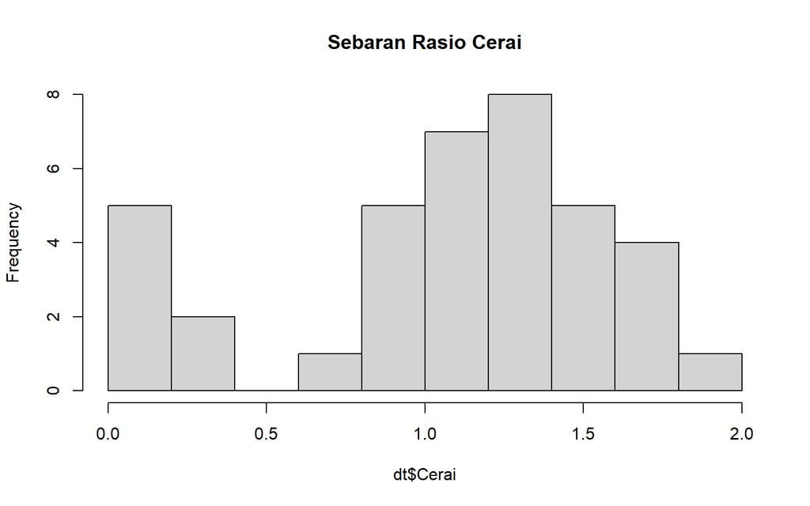

```r
hist(dt$Cerai, main = "Sebaran Rasio Cerai")
```

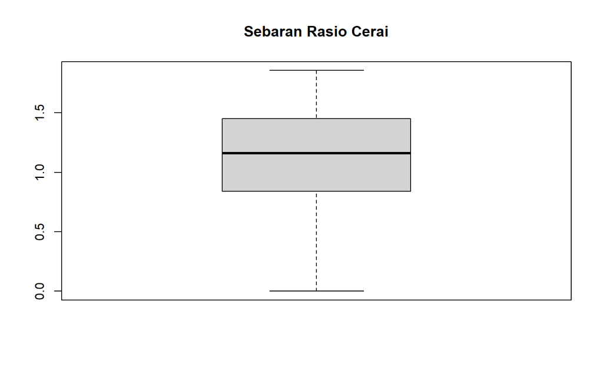

```r
boxplot(dt$Cerai, main = "Sebaran Rasio Cerai")
```

## Peubah Pennjelas vs Peubah Respon

### RLS

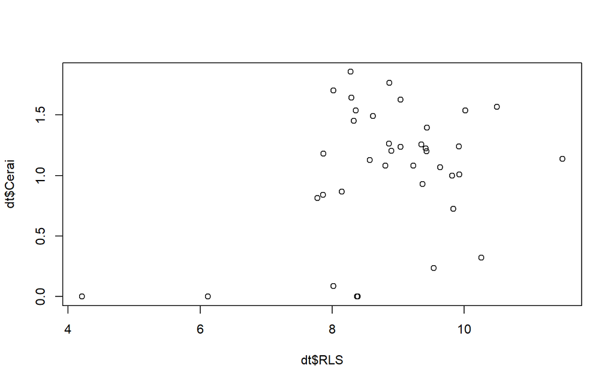

```r
plot(dt$RLS, dt$Cerai)
```

### TPT

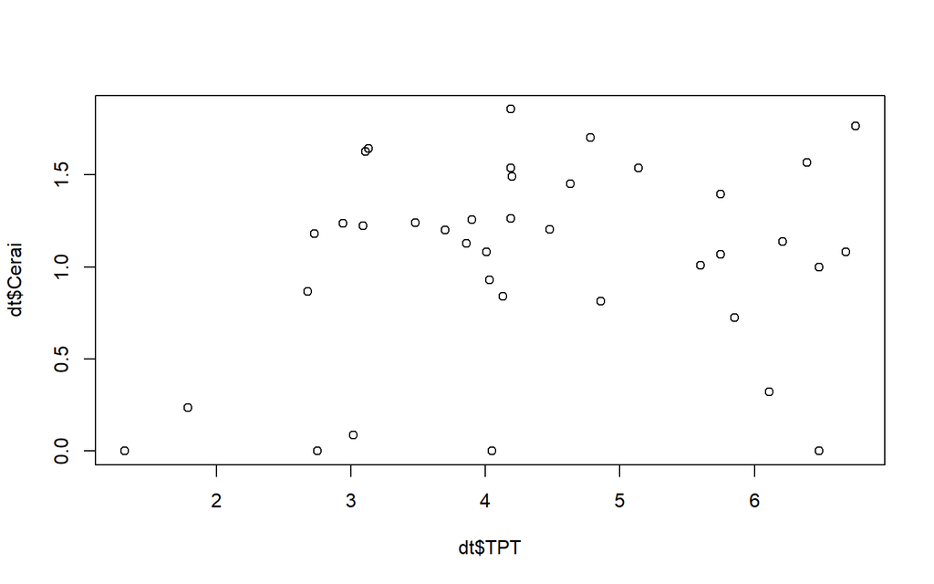

```r
plot(dt$TPT, dt$Cerai)
```

Hubungan antara peubah TPT dan Cerai cenderung tidak linear, ada satu amatan dengan nilai X jauh dari amatan lainnya. Jika amatan tersebut disisihkan, hubungan linearitas akan lebih terlihat.

### PDRB

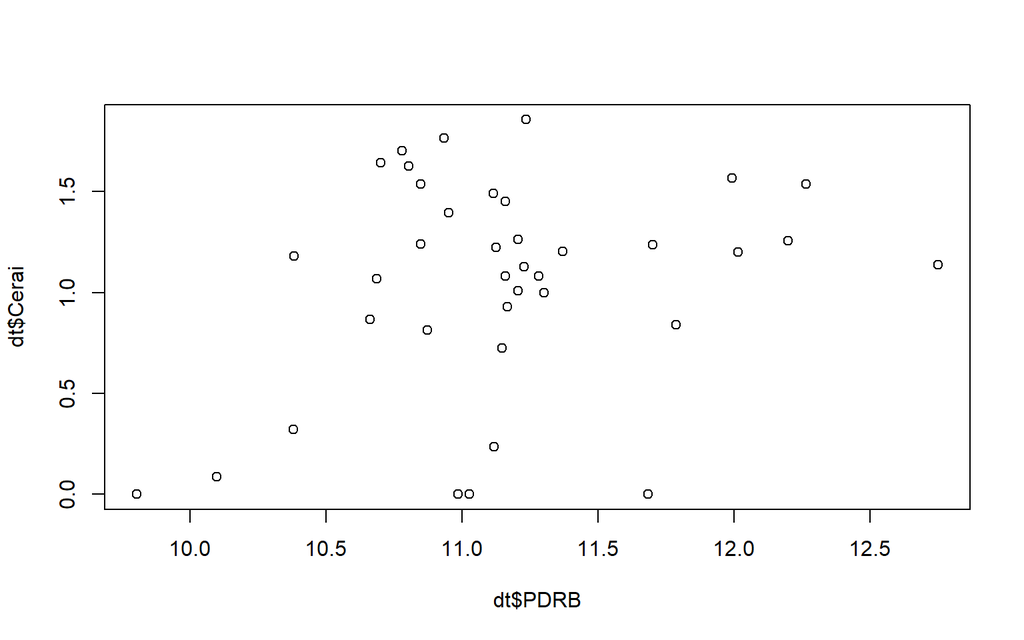

```r
plot(dt$PDRB, dt$Cerai)
```

### KP

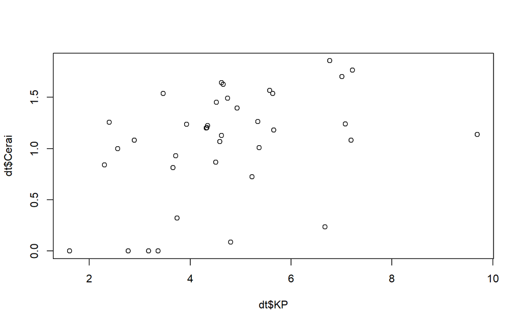

```r
plot(dt$KP, dt$Cerai)
```

Hubungan antara peubah KP dan Cerai cenderung tidak linear, ada satu amatan dengan nilai X jauh dari amatan lainnya.

# PPM

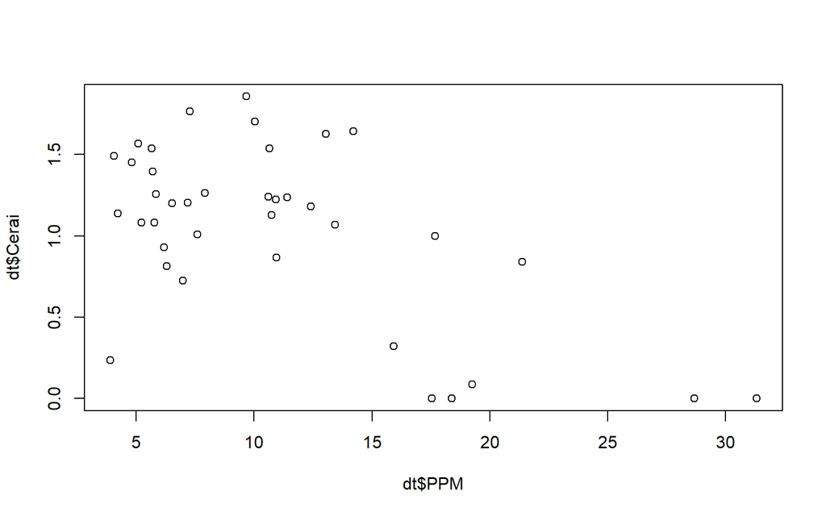

```r
plot(dt$PPM, dt$Cerai)
```

## Korelasi

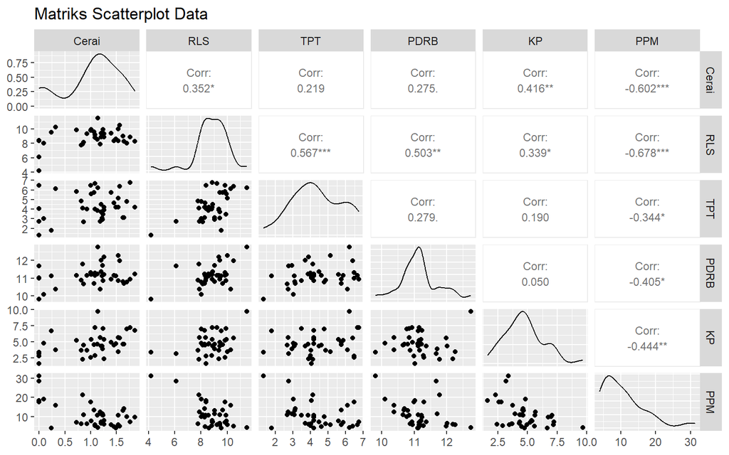

```r
ggpairs(dt,
        upper = list(continuous = wrap('cor', size = 3)),
        title = "Matriks Scatterplot Data")
```

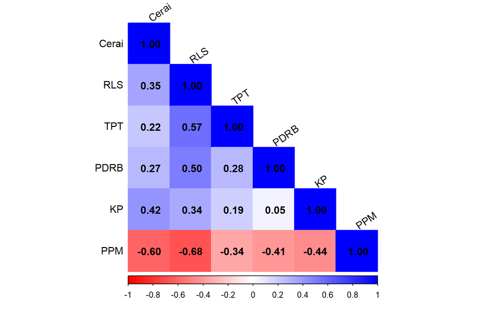

```r
cor_matrix <- cor(dt, use = "complete.obs")

corrplot(cor_matrix, method = "color", type = "lower",
         col = colorRampPalette(c("red", "white", "blue"))(200),
         addCoef.col = "black", tl.col = "black", tl.srt = 35)
```

Hasil matriks scatter plot dan korelasi menunjukkan bahwa peubah respon Cerai memiliki hubungan positif dengan RLS (0.35), TPT (0.22), PDRB (0.27), dan KP (0.42), serta hubungan negatif dengan PPM (-0.60). Selain itu, terdapat korelasi tinggi antar peubah penjelas, baik lebih dari 0.5 maupun kurang dari -0.5. Beberapa di antaranya adalah:

RLS dan TPT memiliki korelasi positif sebesar 0.57. RLS dan PDRB memiliki korelasi positif sebesar 0.50. PPM dengan RLS menunjukkan korelasi negatif yang cukup kuat, yaitu -0.68. PPM dengan KP menunjukkan korelasi negatif sebesar -0.44. PPM dengan PDRB menunjukkan korelasi negatif sebesar -0.41.

Korelasi yang tinggi ini mengindikasikan adanya potensi multikolinearitas, yang dapat mempengaruhi keakuratan model yang akan dibentuk.

# Pemodelan

```r
model1 = lm(formula = Cerai ~ ., data = dt)
summary(model1)
```

```
##
## Call:
## lm(formula = Cerai ~ ., data = dt)
##
## Residuals:
##      Min       1Q   Median       3Q      Max
## -1.14420 -0.24487  0.07062  0.28455  0.79058
##
## Coefficients:
##             Estimate Std. Error t value Pr(>|t|)
## (Intercept)  0.76597    1.67798   0.456  0.65113
## RLS         -0.09045    0.09681  -0.934  0.35716
## TPT          0.02457    0.06243   0.394  0.69655
## PDRB         0.10461    0.14572   0.718  0.47803
## KP           0.06794    0.04972   1.366  0.18133
## PPM         -0.04732    0.01609  -2.941  0.00604 **
## ---
## Signif. codes:  0 '***' 0.001 '**' 0.01 '*' 0.05 '.' 0.1 ' ' 1
##
## Residual standard error: 0.4413 on 32 degrees of freedom
## Multiple R-squared:  0.4099, Adjusted R-squared:  0.3177
## F-statistic: 4.446 on 5 and 32 DF,  p-value: 0.00346
```

Persamaan yang terbentuk adalah
$$\hat{Cerai}=0.76597−0.0904RLS+0.0246TPT+0.1046PDRB+0.0679KP-0.0473PPM$$

Pada ringkasan model ini dapat dilihat bahwa secara simultan minimal ada satu peubah penjelas yang berpengaruh signifikan terhadap Rasio Cerai. Hal tersebut selaras karena terdapat dugaan parameter yang signifikan pada taraf nyata 5%, yaitu peubah PPM. Peubah RLS mengalami perubahan tanda dalam dugaan parameternya jika dibandingkan dengan arah korelasi, sehingga mengindikasi ada permasalahan dalam model. Selanjutnya diperlukan pengujian asumsi pada model, dimulai dengan pemeriksaan multikolinearitas dilanjutkan dengan diagnosis sisaan

# Pemeriksaan Multikolinearitas

## Perubahan Peubah

```r
mod1 <- lm(Cerai ~ ., dt[1:2])
mod2 <- lm(Cerai ~ ., dt[1:3])
mod3 <- lm(Cerai ~ ., dt[1:4])
mod4 <- lm(Cerai ~ ., dt[1:5])
mod5 <- lm(Cerai ~ ., dt)

stargazer(mod1, mod2, mod3, mod4, mod5,
          type = "text", single.row = TRUE)
```

```
##
## ==========================================================================================================================
##                                                              Dependent variable:
##                     ------------------------------------------------------------------------------------------------------
##                                                                     Cerai
##                             (1)                  (2)                (3)                 (4)                   (5)
## --------------------------------------------------------------------------------------------------------------------------
## RLS                   0.153** (0.068)      0.146* (0.084)      0.117 (0.093)       0.051 (0.093)        -0.090 (0.097)
## TPT                                         0.011 (0.073)      0.011 (0.073)       0.012 (0.069)         0.025 (0.062)
## PDRB                                                           0.119 (0.167)       0.172 (0.160)         0.105 (0.146)
## KP                                                                                0.116** (0.052)        0.068 (0.050)
## PPM                                                                                                    -0.047*** (0.016)
## Constant               -0.309 (0.606)      -0.294 (0.622)      -1.365 (1.631)      -1.918 (1.563)        0.766 (1.678)
## --------------------------------------------------------------------------------------------------------------------------
## Observations                 38                  38                  38                  38                   38
## R2                         0.124                0.125              0.137               0.250                 0.410
## Adjusted R2                0.100                0.074              0.061               0.160                 0.318
## Residual Std. Error   0.507 (df = 36)      0.514 (df = 35)    0.518 (df = 34)     0.490 (df = 33)       0.441 (df = 32)
## F Statistic         5.094** (df = 1; 36) 2.489* (df = 2; 35) 1.804 (df = 3; 34) 2.756** (df = 4; 33) 4.446*** (df = 5; 32)
## ==========================================================================================================================
## Note:                                                                                          *p<0.1; **p<0.05; ***p<0.01
```

Terdapat perubahan tanda arah korelasi pada beberapa peubah, serta perubahan dugaan parameter yang cukup besar ketika ditambahkan peubah lainnya. Hasil ini mengindikasi adanya permasalahan dalam model.

## Perubahan Banyak Data

```r
mod5_1 <- lm(PPM ~ ., dt[1:15,])
stargazer(summary(mod5)$coefficients, summary(mod5_1)$coefficients,
          type = "text",
          font.size = "small")
```

```
##
## ===================================================
##             Estimate Std. Error t value Pr(> | t| )
## ---------------------------------------------------
## (Intercept)  0.766     1.678     0.456     0.651
## RLS          -0.090    0.097    -0.934     0.357
## TPT          0.025     0.062     0.394     0.697
## PDRB         0.105     0.146     0.718     0.478
## KP           0.068     0.050     1.366     0.181
## PPM          -0.047    0.016    -2.941     0.006
## ---------------------------------------------------
##
## ===================================================
##             Estimate Std. Error t value Pr(> | t| )
## ---------------------------------------------------
## (Intercept)  52.078    14.140    3.683     0.005
## Cerai        -0.593    2.969    -0.200     0.846
## RLS          0.842     1.125     0.749     0.473
## TPT          -1.191    0.605    -1.969     0.080
## PDRB         -4.128    1.378    -2.995     0.015
## KP           0.285     0.495     0.575     0.579
## ---------------------------------------------------
```

Terdapat dugaan parameter yang mengalami perubahan besar ketika jumlah amatan berbeda, mengindikasi model bermasalah.

## Akar Ciri

```r
x <- dt[-1]
r <- cor(x)
(ev <- eigen(r)$values)
```

```
## [1] 2.5965185 0.9798400 0.7277942 0.4414022 0.2544451
```

```r
# Simultan
if ((max(ev) / min(ev)) <= 100) {
  cat("Tidak ada multikolinearitas\n")
} else if ((max(ev) / min(ev)) > 100 & (max(ev) / min(ev)) <= 1000) {
  cat("Ada multikolinearitas yang lemah\n")
} else {
  cat("Ada multikolinearitas yang kuat\n")
}
```

```
## Tidak ada multikolinearitas
```

```r
# Parsial
if (all((max(ev) / ev) <= 1000)) {
  cat("Tidak ada multikolinearitas\n")
} else {
  cat("Ada multikolinearitas pada peubah penjelas ke:", which((max(ev) / ev) > 1000), "\n")
}
```

```
## Tidak ada multikolinearitas
```

## Nilai VIF

```r
vif(model1)
```

```
##      RLS      TPT     PDRB       KP      PPM
## 2.684764 1.481184 1.403081 1.297289 2.109031
```

Hasil pemeriksaan dengan akar ciri menyatakan tidak ada multikolinearitas pada model karena tidak ada nilai $k>100$ secara simultan. Nilai VIF juga menunjukkan tidak ada peubah yang VIF-nya lebih dari 10, sehingga tidak ditemukan indikasi multikolinearitas yang serius. Pada analisis ini, model penuh dengan seluruh peubah penjelas (RLS, TPT, PDRB, KP, PPM) tetap digunakan untuk tahap selanjutnya.

# Pemodelan Penyisihan Peubah

```r
model2 <- lm(Cerai ~ RLS + TPT + PDRB + KP + PPM, data = dt)
summary(model2)
```

```
##
## Call:
## lm(formula = Cerai ~ RLS + TPT + PDRB + KP + PPM, data = dt)
##
## Residuals:
##      Min       1Q   Median       3Q      Max
## -1.14420 -0.24487  0.07062  0.28455  0.79058
##
## Coefficients:
##             Estimate Std. Error t value Pr(>|t|)
## (Intercept)  0.76597    1.67798   0.456  0.65113
## RLS         -0.09045    0.09681  -0.934  0.35716
## TPT          0.02457    0.06243   0.394  0.69655
## PDRB         0.10461    0.14572   0.718  0.47803
## KP           0.06794    0.04972   1.366  0.18133
## PPM         -0.04732    0.01609  -2.941  0.00604 **
## ---
## Signif. codes:  0 '***' 0.001 '**' 0.01 '*' 0.05 '.' 0.1 ' ' 1
##
## Residual standard error: 0.4413 on 32 degrees of freedom
## Multiple R-squared:  0.4099, Adjusted R-squared:  0.3177
## F-statistic: 4.446 on 5 and 32 DF,  p-value: 0.00346
```

Persamaan yang terbentuk adalah

$$\hat{Cerai}=0.76597−0.0904RLS+0.0246TPT+0.1046PDRB+0.0679KP-0.0473PPM$$

Pada ringkasan model ini dapat dilihat bahwa secara simultan minimal ada satu peubah penjelas yang berpengaruh signifikan terhadap Rasio Cerai. Selanjutnya perlu dilakukan uji asumsi pada model untuk memeriksa kelayakannya.

## Nilai VIF

```r
vif(model2)
```

```
##      RLS      TPT     PDRB       KP      PPM
## 2.684764 1.481184 1.403081 1.297289 2.109031
```

Model menunjukkan bahwa nilai VIF < 10 untuk seluruh peubah penjelas, sehingga dinyatakan tidak terjadi multikolinearitas. Selanjutnya perlu dilakukan uji asumsi dan pemeriksaan pencilan, leverage, dan amatan berpengaruh.

# Pengujian Asumsi

## Eksplorasi Grafik

### Plot Sisaan vs Y duga

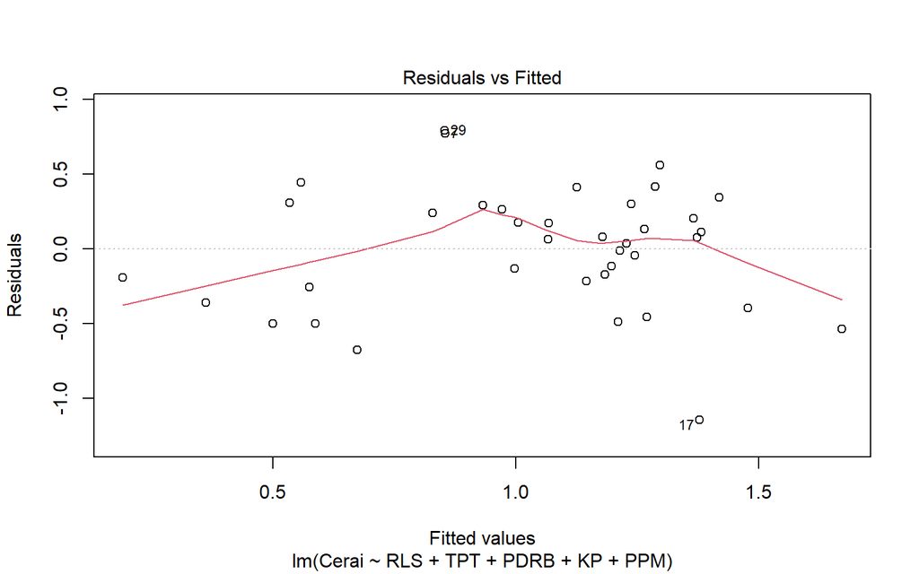

```r
plot(model2,1)
```

### Plot Sisaan vs Urutan

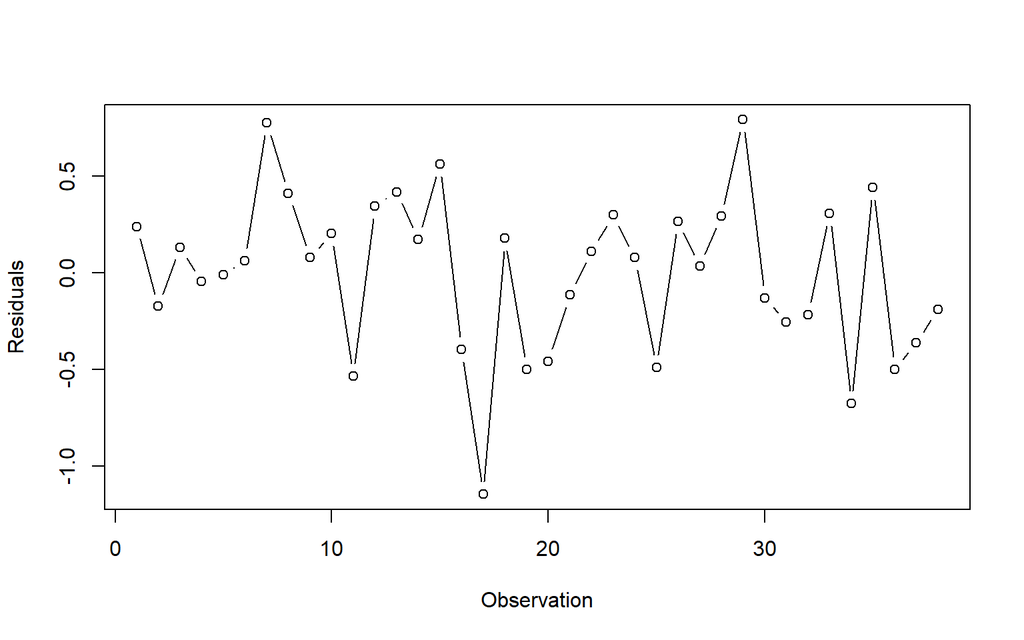

```r
plot(x = 1:dim(dt)[1],
     y = model2$residuals,
     type = 'b',
     ylab = "Residuals",
     xlab = "Observation")
```

Tebaran tidak berpola sehingga dapat disimpulkan bahwa sisaan saling bebas dan tidak terdapat indikasi autokorelasi pada model.

### QQ plot

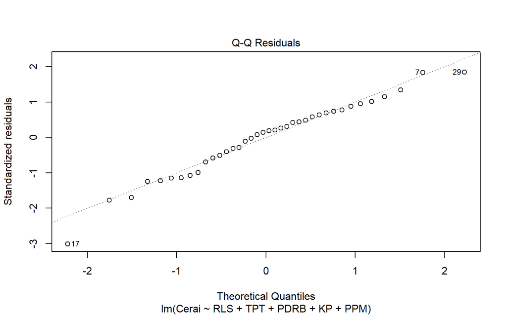

```r
plot(model2,2)
```

## Uji Formal

### Nilai harapan sisaan sama dengan nol

```r
t.test(model2$residuals,mu = 0,conf.level = 0.95)
```

```
##
##  One Sample t-test
##
## data:  model2$residuals
## t = 2.175e-17, df = 37, p-value = 1
## alternative hypothesis: true mean is not equal to 0
## 95 percent confidence interval:
##  -0.134891  0.134891
## sample estimates:
##    mean of x
## 1.447981e-18
```

Nilai p pada uji t sama dengan 1 yang lebih besar dari alpha 5%, sehingga dinyatakan asumsi nilai harapan sisaan sama dengan nol terpenuhi

### Ragam sisaan homogen

```r
bptest(model2)
```

```
##
##  studentized Breusch-Pagan test
##
## data:  model2
## BP = 5.6693, df = 5, p-value = 0.3397
```

Nilai p pada uji breusch pagan sama dengan 0.3397 yang lebih besar dari alpha 5%, sehingga dinyatakan asumsi ragam sisaan homogen terpenuhi

### Sisaan saling bebas

```r
dwtest(model2)
```

```
##
##  Durbin-Watson test
##
## data:  model2
## DW = 1.9368, p-value = 0.2987
## alternative hypothesis: true autocorrelation is greater than 0
```

Nilai p pada uji durbin watson sama dengan 0.2987 yang lebih besar dari alpha 5%, sehingga dinyatakan asumsi sisaan saling bebas terpenuhi

### Normalitas Sisaan

```r
shapiro.test(model2$residuals)
```

```
##
##  Shapiro-Wilk normality test
##
## data:  model2$residuals
## W = 0.97765, p-value = 0.634
```

Nilai p pada uji shapiro wilk sama dengan 0.634 yang lebih besar dari alpha 5%, sehingga dinyatakan asumsi normalitas sisaan terpenuhi

Semua asumsi sisaan terpenuhi, tetapi model masih perlu diperiksa lebih lanjut kemungkinan karena keberadaan amatan yang tidak biasa seperti pencilan, leverage, atau amatan berpengaruh.

# Pemeriksaan Amatan Tidak Biasa

```r
#fungsi
ri_stud <- rstudent(model2)
ri_stan <- rstandard(model2)
hii_fungsi <- hatvalues(model2)

#manual
X <- model.matrix(model2)
X_inv_xt <- X %*% solve(t(X) %*% X) %*% t(X)
hii_manual <- diag(X_inv_xt)
anova_model <- anova(model2)
s <- sqrt(anova_model["Residuals", "Mean Sq"])
ei <- model2$residuals
ri_manual <- ei/(s*sqrt(1-hii_manual))

nilai <- data.frame(ri_stud, ri_stan, ri_manual, hii_fungsi, hii_manual)
nilai
```

```
##        ri_stud     ri_stan   ri_manual hii_fungsi hii_manual
## 1   0.57167661  0.57778638  0.57778638 0.12316720 0.12316720
## 2  -0.39816669 -0.40350730 -0.40350730 0.05762158 0.05762158
## 3   0.30823754  0.31269085  0.31269085 0.08462038 0.08462038
## 4  -0.10480636 -0.10646451 -0.10646451 0.11282573 0.11282573
## 5  -0.02630752 -0.02672817 -0.02672817 0.04955665 0.04955665
## 6   0.14371289  0.14596382  0.14596382 0.03285175 0.03285175
## 7   1.91464550  1.83955310  1.83955310 0.09283310 0.09283310
## 8   0.95135873  0.95277281  0.95277281 0.04909112 0.04909112
## 9   0.18552400  0.18838802  0.18838802 0.12201446 0.12201446
## 10  0.48247170  0.48836161  0.48836161 0.11424261 0.11424261
## 11 -1.83613475 -1.77166248 -1.77166248 0.53238051 0.53238051
## 12  0.87786990  0.88103277  0.88103277 0.21175384 0.21175384
## 13  1.01864893  1.01805028  1.01805028 0.13891518 0.13891518
## 14  0.43104541  0.43663603  0.43663603 0.19692859 0.19692859
```

[output cut: 24 more lines]

## Pencilan

```r
for (i in 1:dim(nilai)[1]){
  absri <- abs(nilai[,2])
  pencilan <- which(absri > 2)
}
pencilan
```

```
## [1] 17
```

Amatan ke-17 terdeteksi sebagai pencilan

## Leverage

```r
n <- dim(dt)[1]
p <- length(model2$coefficients)

for (i in 1:dim(nilai)[1]){
  cutoff <- 2*p/n
  titik_leverage <- which(hii_fungsi > cutoff)
}
titik_leverage
```

```
## 11 31 37 38
## 11 31 37 38
```

Amatan ke-11, 31, 37, dan 38 terdeteksi sebagai titik leverage

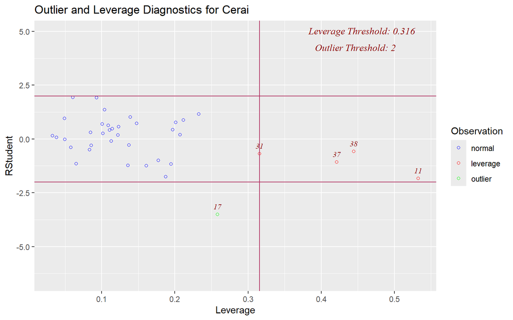

```r
ols_plot_resid_lev(model2)
```

Plot yang terbentuk dari fungsi `ols_plot_resid_lev()` menunjukkan amatan-amatan yang termasuk sebagai pencilan/outlier maupun leverage. Hal ini dikarenakan perbedaan rumusan yang dipakai pada `rstandard()` dan `rstudent()`.

## Amatan Berpengaruh

### Jarak Cook

```r
di <- cooks.distance(model2)
f <- qf(0.05,p,n-p, lower.tail = F)
data.frame(di, di>f)
```

```
##              di di...f
## 1  7.815588e-03  FALSE
## 2  1.659248e-03  FALSE
## 3  1.506443e-03  FALSE
## 4  2.402468e-04  FALSE
## 5  6.208160e-06  FALSE
## 6  1.206159e-04  FALSE
## 7  5.771505e-02  FALSE
## 8  7.810727e-03  FALSE
## 9  8.220140e-04  FALSE
## 10 5.126785e-03  FALSE
## 11 5.955802e-01  FALSE
## 12 3.475380e-02  FALSE
## 13 2.786705e-02  FALSE
## 14 7.791884e-03  FALSE
```

[output cut: 24 more lines]

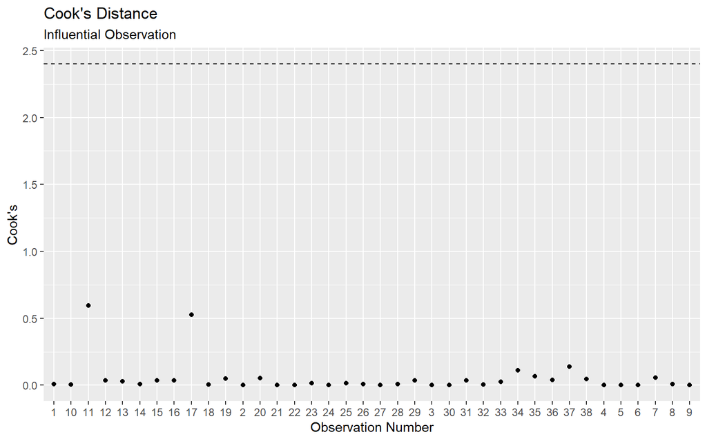

```r
cooks_crit = f
model_cooks <- cooks.distance(model2)
df <- data.frame(obs = names(model_cooks),
                 cooks = model_cooks)
ggplot(df, aes(y = cooks, x = obs)) +
  geom_point() +
  geom_hline(yintercept = cooks_crit, linetype="dashed") +
  labs(title = "Cook's Distance",
       subtitle = "Influential Observation ",
       x = "Observation Number",
       y = "Cook's")
```

Pemeriksaan amatan berpengaruh dengan jarak cook tidak dihasilkan nilai yang melebihi ambang batas

### DFBETAS

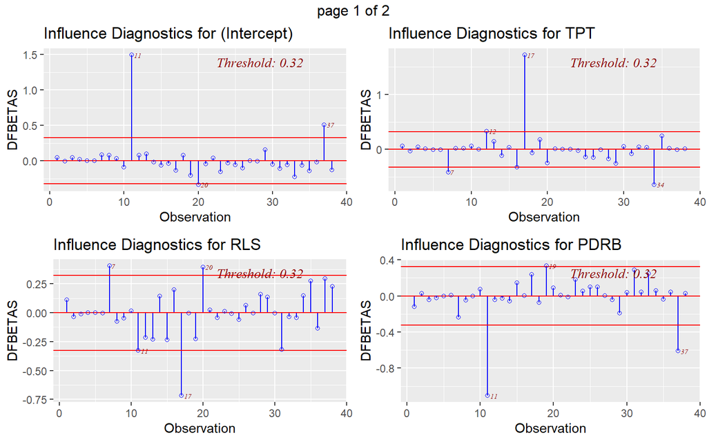

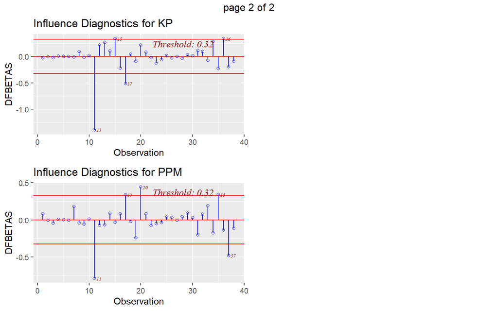

```r
ols_plot_dfbetas(model2)
```

Hasil DFBETAS akan menunjukkan pengaruh observasi terhadap setiap koefisien regresi, sehingga ada output untuk setiap parameter regresi. DFBETAS mengukur seberapa besar koefisien regresi berubah jika suatu observasi dihapus dari model.

### DFFITS

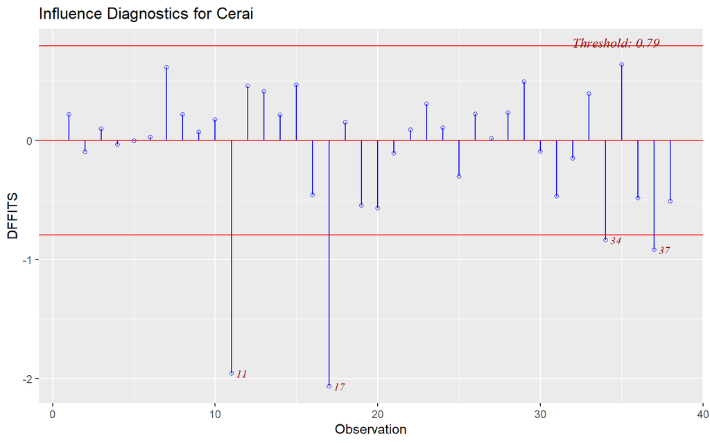

```r
ols_plot_dffits(model2)
```

Hasil DFFITS menunjukkan pengaruh observasi terhadap nilai prediksi Y, sehingga hanya menghasilkan satu output. DFFITS mengukur seberapa besar nilai prediksi $\hat{Y}_i$ berubah jika suatu observasi dihapus dari model, sehingga lebih tepat digunakan jika ingin melihat pengaruh observasi terhadap hasil model secara keseluruhan

```r
DFFITSi <- dffits(model2)

amatan_berpengaruh <- vector("list", dim(nilai)[1])
for (i in 1:dim(nilai)[1]) {
  cutoff <- 2 * sqrt((p / n))
  amatan_berpengaruh[[i]] <- which(abs(DFFITSi) > cutoff)
}
berpengaruh <- unlist(amatan_berpengaruh)
amatan_berpengaruh <- sort(unique(berpengaruh))
amatan_berpengaruh
```

```
## [1] 11 17 34 37
```

Amatan ke-11, 17, 34 dan 37 termasuk amatan berpengaruh sehingga sangat riskan jika disisihkan. Perlu ditelusuri lebih lanjut

# Pemodelan Penyisihan Amatan

```r
# gunakan peubah penjelas yang sudah diseleksi

# Sisihkan satu per satu
dt1 <- dt %>% slice(-11)
model3 <- lm(Cerai ~ ., dt1)

dt2 <- dt %>% slice(-17)
model4 <- lm(Cerai ~ ., dt2)

dt3 <- dt %>% slice(-34)
model5 <- lm(Cerai ~ ., dt3)

dt4 <- dt %>% slice(-37)
model6 <- lm(Cerai ~ ., dt4)

# Sisihkan kombinasi dua
dt5 <- dt %>% slice(-c(11, 17))
model7 <- lm(Cerai ~ ., dt5)

dt6 <- dt %>% slice(-c(11, 34))
model8 <- lm(Cerai ~ ., dt6)

dt7 <- dt %>% slice(-c(11, 37))
model9 <- lm(Cerai ~ ., dt7)

dt8 <- dt %>% slice(-c(17, 34))
model10 <- lm(Cerai ~ ., dt8)

dt9 <- dt %>% slice(-c(17, 37))
model11 <- lm(Cerai ~ ., dt9)

dt10 <- dt %>% slice(-c(34, 37))
model12 <- lm(Cerai ~ ., dt10)

# Sisihkan kombinasi tiga
dt11 <- dt %>% slice(-c(11, 17, 34))
model13 <- lm(Cerai ~ ., dt11)

dt12 <- dt %>% slice(-c(11, 17, 37))
model14 <- lm(Cerai ~ ., dt12)

dt13 <- dt %>% slice(-c(11, 34, 37))
model15 <- lm(Cerai ~ ., dt13)

dt14 <- dt %>% slice(-c(17, 34, 37))
model16 <- lm(Cerai ~ ., dt14)

# Sisihkan keempatnya
dt15 <- dt %>% slice(-c(11, 17, 34, 37))
model17 <- lm(Cerai ~ ., dt15)
```

```r
get_metrics <- function(model) {
  adj_r2 <- summary(model)$adj.r.squared
  sse <- sum(model$residuals^2)
  return(c(adj_r2, sse))
}

semua_model <- list(model2, model3, model4, model5, model6,
                    model7, model8, model9, model10, model11,
                    model12, model13, model14, model15, model16, model17)

model_metrics <- data.frame(
  Model = c("Model 2 (penuh)",
            "Model 3 (-11)", "Model 4 (-17)", "Model 5 (-34)", "Model 6 (-37)",
            "Model 7 (-11,17)", "Model 8 (-11,34)", "Model 9 (-11,37)",
            "Model 10 (-17,34)", "Model 11 (-17,37)", "Model 12 (-34,37)",
            "Model 13 (-11,17,34)", "Model 14 (-11,17,37)",
            "Model 15 (-11,34,37)", "Model 16 (-17,34,37)",
            "Model 17 (-11,17,34,37)"),
  Adjusted_R2 = sapply(semua_model, function(m) get_metrics(m)[1]),
  SSE = sapply(semua_model, function(m) get_metrics(m)[2])
)

print(model_metrics)
```

```
##                      Model Adjusted_R2      SSE
## 1          Model 2 (penuh)   0.3176935 6.231459
## 2            Model 3 (-11)   0.3814275 5.620233
## 3            Model 4 (-17)   0.4753226 4.466423
## 4            Model 5 (-34)   0.3020364 5.672644
## 5            Model 6 (-37)   0.2609824 6.006308
## 6         Model 7 (-11,17)   0.5839127 3.523905
## 7         Model 8 (-11,34)   0.3629111 5.151750
## 8         Model 9 (-11,37)   0.3630767 5.150410
## 9        Model 10 (-17,34)   0.4332568 4.233916
## 10       Model 11 (-17,37)   0.4175616 4.351168
## 11       Model 12 (-34,37)   0.2424169 5.360003
## 12    Model 13 (-11,17,34)   0.5445597 3.385084
## 13    Model 14 (-11,17,37)   0.5713822 3.185724
## 14    Model 15 (-11,34,37)   0.3483194 4.587469
## 15    Model 16 (-17,34,37)   0.3623267 4.067724
## 16 Model 17 (-11,17,34,37)   0.5284232 2.992442
```

Berdasarkan hasil perbandingan tersebut, didapatkan bahwa model 7 yang menyisihkan amatan ke-11 dan 17 memiliki nilai adjusted R square terbesar tetapi bukan SSE yang terkecil. SSE terkecil terdapat pada model 17 yang menyisihkan amatan ke-11, 17, 34 dan 37

```r
stargazer(model2, model7, model17, type = "text", font.size = "small",
          report = "vc*p")
```

```
##
## ======================================================================================
##                                            Dependent variable:
##                     ------------------------------------------------------------------
##                                                   Cerai
##                              (1)                   (2)                    (3)
## --------------------------------------------------------------------------------------
## RLS                        -0.090                 0.014                 -0.037
##                           p = 0.358             p = 0.864              p = 0.643
##
## TPT                         0.025                 -0.077                -0.043
##                           p = 0.697             p = 0.164              p = 0.450
##
## PDRB                        0.105                 0.267*                0.407**
##                           p = 0.479             p = 0.053              p = 0.011
##
## KP                          0.068                0.176***              0.187***
##                           p = 0.182             p = 0.002              p = 0.001
##
## PPM                       -0.047***              -0.037**               -0.023
##                           p = 0.007             p = 0.011              p = 0.135
##
## Constant                    0.766                 -2.055                -3.496*
##                           p = 0.652             p = 0.232              p = 0.065
##
## --------------------------------------------------------------------------------------
## Observations                 38                     36                    34
## R2                          0.410                 0.643                  0.600
## Adjusted R2                 0.318                 0.584                  0.528
## Residual Std. Error    0.441 (df = 32)       0.343 (df = 30)        0.327 (df = 28)
## F Statistic         4.446*** (df = 5; 32) 10.823*** (df = 5; 30) 8.396*** (df = 5; 28)
## ======================================================================================
## Note:                                                      *p<0.1; **p<0.05; ***p<0.01
```